# Final Exam

Author

Sophie Gill

Published

December 11, 2023

# Introduction

This data analysis explores the H1B 2017 dataset within RStudio and aims to supply an understanding of the information it provides through means of numerical, visual, and regression-based descriptions. The dataset is composed of information about the H-1B visa in the United States, which allows for the employment of foreign workers in specialty occupations. The data includes details of the employers of such individuals, as well as details related to their petition. This report strives to provide insight into this vast amount of information by identifying and interpreting relationships between those variables.

# Data Preparation

This block contains the packages needed to work with the dataset throughout the report. It also provides a glimpse of the raw, chaotic data before any alterations are made.

```r
library(readr)
library(dplyr)
library(ggplot2)
df <- read_tsv("/home/mm223266/data/h1b-2017-half.tsv")
glimpse(df)
```

```
Rows: 312,322
Columns: 53
$ ...1                        <dbl> 346361, 268657, 54363, 402221, 370773, 441…
$ CASE_NUMBER                 <chr> "I-200-17076-215306", "I-200-17067-247998"…
$ CASE_STATUS                 <chr> "CERTIFIED", "CERTIFIED", "CERTIFIED", "CE…
$ CASE_SUBMITTED              <date> 2017-03-17, 2017-03-08, 2016-11-18, 2017-…
$ DECISION_DATE               <date> 2017-03-23, 2017-03-14, 2016-11-25, 2017-…
$ VISA_CLASS                  <chr> "H-1B", "H-1B", "H-1B", "H-1B", "H-1B", "H…
$ EMPLOYMENT_START_DATE       <date> 2017-09-13, 2017-09-07, 2016-11-24, 2017-…
$ EMPLOYMENT_END_DATE         <date> 2020-09-12, 2020-09-06, 2019-11-23, 2020-…
$ EMPLOYER_NAME               <chr> "KNACK SYSTEMS LLC", "DELTA PRODUCTS CORPO…
$ EMPLOYER_BUSINESS_DBA       <chr> NA, NA, NA, NA, NA, NA, NA, NA, NA, NA, NA…
$ EMPLOYER_ADDRESS            <chr> "1 WOODBRIDGE CENTER", "46101 FREMONT BLVD…
$ EMPLOYER_CITY               <chr> "WOODBRIDGE", "FREMONT", "CHICAGO", "SAN J…
$ EMPLOYER_STATE              <chr> "NJ", "CA", "IL", "CA", "TX", "IL", "CA", …
```

[output cut: 40 more lines]

To begin narrowing down the dataset, I evaluated the different visas and employer countries present. The following small tables display how the H-1B visa and the USA are the only factors I should consider in terms of those variables.

```r
visa_class_counts <- table(df$VISA_CLASS)
visa_class_counts
```

```
 E-3 Australian            H-1B     H-1B1 Chile H-1B1 Singapore
           6001          305215             468             638
```

```r
employer_country_counts <- table(df$EMPLOYER_COUNTRY)
employer_country_counts
```

```
               AUSTRALIA                 CAMBODIA                   CANADA
                       2                        1                        4
                   CHINA UNITED STATES OF AMERICA
                       1                   263878
```

After reviewing the raw dataset, I distinguished the variables I thought to be the most significant for comparison purposes. This block creates a new dataframe (df2) that only takes into account my chosen columns, and filters the visa class and employer country variables as decided above. Finally, ‘na.omit()’ further cleans up the data by removing all observations with missing information throughout any variable in the set. I will be using df2 for the remainder of my exploration.

```r
#create new data frame with just H1B visas, USA as employer country, and desired variables
df2 <- df |>
  filter(VISA_CLASS == 'H-1B') |>
  filter(EMPLOYER_COUNTRY == 'UNITED STATES OF AMERICA') |>
  select(c("CASE_STATUS", "DECISION_DATE", "EMPLOYER_NAME", "JOB_TITLE", "PREVAILING_WAGE", "WORKSITE_STATE", "CASE_SUBMITTED")) |>
  na.omit()
```

# Numerical Summary

In this section, I begin experimenting with variable relationships and analyzing what the results may imply. Firstly, I was curious about the application distribution across the USA. This table displays the count of visa applications per state, showing that California receives the highest amount.

```r
state_table <- table(df2$WORKSITE_STATE)
state_table
```

```
     AK      AL      AR      AZ      CA      CO      CT      DC      DE      FL
     92     709    1235    3993   49316    2575    3462    1654    1366    9120
     FM      GA      GU      HI      IA      ID      IL      IN      KS      KY
      1    9441     107     206    1289     347   13394    2579    1181    1163
     LA      MA      MD      ME      MI      MN      MO      MP      MS      MT
    825   10468    4412     281    8612    4370    3452     126     306      81
     NC      ND      NE      NH      NJ      NM      NV      NY      OH      OK
   7028     192     896     582   18340     333     583   21684    6286     697
     OR      PA      PR      PW      RI      SC      SD SUBJECT      TN      TX
   1899    8872     263       1    1011    1207     112       1    2814   27812
     UT      VA      VI      VT      WA      WI      WV      WY
   1240    7467      18     169    9808    2728     224      66
```

Taking the states with the most applications, I am now displaying the count of the most popular jobs in those areas.

```r
df2 |>
  filter(WORKSITE_STATE %in% c("CA", "IL", "NJ", "NY", "TX", "WA", "PA", "MA", "GA", "FL")) |>
  filter(JOB_TITLE %in% c("PROGRAMMER ANALYST", "SOFTWARE ENGINEER", "SOFTWARE DEVELOPER", "SYSTEMS ANALYST", "COMPUTER PROGRAMMER", "CONSULTANT", "BUSINESS ANALYST")) |>
  with(addmargins(table(JOB_TITLE, WORKSITE_STATE)))
```

```
                     WORKSITE_STATE
JOB_TITLE                CA    FL    GA    IL    MA    NJ    NY    PA    TX
  BUSINESS ANALYST      424   142   127   108   119   393   225   138   400
  COMPUTER PROGRAMMER   466    80   149   251   152   407   141   161   505
  CONSULTANT            241    32    67   104    74   114   112   101   155
  PROGRAMMER ANALYST   2270   897   920  1071   662  3186   834   853  3008
  SOFTWARE DEVELOPER    708   430   408   423   192   665   327   269   936
  SOFTWARE ENGINEER    3228   423   388   481   516   588   587   259  1108
  SYSTEMS ANALYST       535   187   302   264   114   347   154   204   818
  Sum                  7872  2191  2361  2702  1829  5700  2380  1985  6930
                     WORKSITE_STATE
JOB_TITLE                WA   Sum
  BUSINESS ANALYST       70  2146
  COMPUTER PROGRAMMER    27  2339
  CONSULTANT             51  1051
  PROGRAMMER ANALYST    450 14151
  SOFTWARE DEVELOPER    144  4502
  SOFTWARE ENGINEER     957  8535
  SYSTEMS ANALYST       111  3036
  Sum                  1810 35760
```

It can now be seen that computer developers, programmers, and system analysts are the occupations which contribute to the maximum share of H1B applications. This suggests that there may have been high demand for computer engineers in the US during 2017.

I then wanted to know if the popularity of these jobs had any correlation to the likelihood or frequency of their application being certified. The following comparison depicts the predominant case status of the same jobs viewed above.

```r
selected_jobs <- c("PROGRAMMER ANALYST", "SOFTWARE ENGINEER", "SOFTWARE DEVELOPER",
                   "SYSTEMS ANALYST", "COMPUTER PROGRAMMER", "CONSULTANT", "BUSINESS ANALYST")

summary_table <- df2 %>%
  filter(JOB_TITLE %in% selected_jobs) %>%
  group_by(JOB_TITLE) %>%
  summarize(
    Predominant_Case_Status = names(sort(table(CASE_STATUS), decreasing = TRUE)[1]),
    Total_Applicants = n()
  )
summary_table
```

```
# A tibble: 7 × 3
  JOB_TITLE           Predominant_Case_Status Total_Applicants
  <chr>               <chr>                              <int>
1 BUSINESS ANALYST    CERTIFIED                           3193
2 COMPUTER PROGRAMMER CERTIFIED                           3351
3 CONSULTANT          CERTIFIED                           1543
4 PROGRAMMER ANALYST  CERTIFIED                          20575
5 SOFTWARE DEVELOPER  CERTIFIED                           6717
6 SOFTWARE ENGINEER   CERTIFIED                          11760
7 SYSTEMS ANALYST     CERTIFIED                           4416
```

Although a high majority of the applications for these jobs were certified, it is important to acknowledge that it’s less likely that there is a significant relationship between the variables due to the vastly higher amount of applications these positions receive.

Despite that lack of likely correlation, I still wanted to further investigate potential relationships with those common job titles. I am now determining if they possess any affiliation with the turnaround time for an application being processed. I was curious to know if the high demand for these jobs meant fewer days elapsed between when the application was submitted and when the results were received. The following block uses the ‘difftime’ function to create the variable ‘daysElapsed’ for this purpose.

```r
# Assuming df2 is your dataframe
df2 <- df2 %>%
  mutate(daysElapsed = as.integer(difftime(DECISION_DATE, CASE_SUBMITTED, units = "days")))

summary(df2$daysElapsed)
```

```
   Min. 1st Qu.  Median    Mean 3rd Qu.    Max.
   0.00    6.00    6.00   33.34    6.00 1890.00
```

This chart compares jobs with their average days elapsed using the new ‘daysElapsed’ variable.

```r
df2 |>
  group_by(JOB_TITLE) |>
  summarize(
    Total_Applicants = n(),
    Average_Days_Elapsed = mean(daysElapsed, na.rm = TRUE)
  ) |>
  arrange(desc(Total_Applicants)) |>
  head(10)
```

```
# A tibble: 10 × 3
   JOB_TITLE                Total_Applicants Average_Days_Elapsed
   <chr>                               <int>                <dbl>
 1 PROGRAMMER ANALYST                  20575                42.8
 2 SOFTWARE ENGINEER                   11760                48.9
 3 SOFTWARE DEVELOPER                   6717                27.3
 4 SYSTEMS ANALYST                      4416                39.3
 5 COMPUTER PROGRAMMER                  3351                41.9
 6 BUSINESS ANALYST                     3193                28.9
 7 COMPUTER SYSTEMS ANALYST             2799                23.7
 8 SENIOR SOFTWARE ENGINEER             2731                33.8
 9 DEVELOPER                            2366                 7.71
10 ASSISTANT PROFESSOR                  1965                91.9
```

From this information, there doesn’t seem to be a strong relationship between these variables either. Although the most popular jobs tend to have a consistent range of turnaround times, the less popular ones don’t seem to show a slower time frame, as would be needed to draw any conclusions.

Overall, these initial summaries provide a good foundation for my forthcoming work on the dataset. I was able to determine the most common states to receive applications, as well as the jobs most applied for there. However, there don’t appear to be any definitive relationships between variables as of yet. The visual summaries will delve further into this research, extracting more insight from what I’ve found where applicable.

# Visual Summary

The visualization process will help me to further prove or disprove any relationships between variables explored before. Additionally, this section will ideally make the information more comprehensible.

The following bar chart utilizes the top states established before and compares them to the top jobs in those places. It confirms those most popular jobs to be accurate and emphasizes the extensive amount of programmer analyst applications.

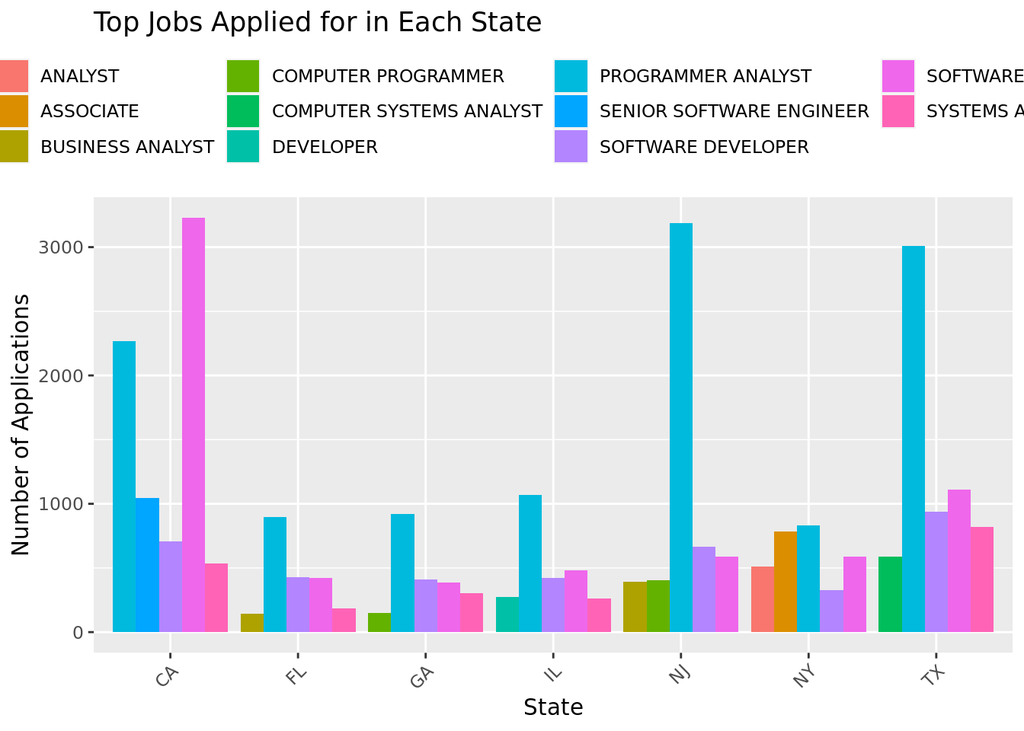

```r
selected_states <- c("CA", "IL", "NJ", "NY", "TX", "FL", "GA")
filtered_data <- df2[df2$WORKSITE_STATE %in% selected_states,]

# Calculate the top jobs for each state
top_jobs_by_state <- filtered_data %>%
  group_by(WORKSITE_STATE, JOB_TITLE) %>%
  summarize(JobCount = n()) %>%
  arrange(desc(JobCount)) %>%
  group_by(WORKSITE_STATE) %>%
  slice_max(order_by = JobCount, n = 5)
# Create grouped bar plot
bar_plot <- ggplot(top_jobs_by_state, aes(x = WORKSITE_STATE, y = JobCount, fill = JOB_TITLE)) +
  geom_bar(stat = "identity", position = "dodge") +
  labs(title = "Top Jobs Applied for in Each State",
       x = "State",
       y = "Number of Applications") +
  theme(axis.text.x = element_text(angle = 45, hjust = 1),
        legend.position = "top",      # Adjust legend position
        legend.title = element_blank())  # Remove legend title for better clarity

print(bar_plot)
```

This next bar chart depicts the relationship between the top jobs and their case status as analyzed numerically earlier. It reveals that the top jobs were not only more certified because of their high count, but also because a majority of applications in general are certified.

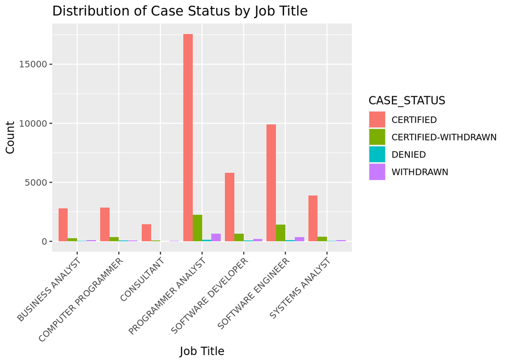

```r
selected_jobs <- c("PROGRAMMER ANALYST", "SOFTWARE ENGINEER", "SOFTWARE DEVELOPER",
                          "SYSTEMS ANALYST", "COMPUTER PROGRAMMER", "CONSULTANT", "BUSINESS ANALYST")
filtered_data <- df2[df2$JOB_TITLE %in% selected_jobs,]

ggplot(filtered_data, aes(x = JOB_TITLE, fill = CASE_STATUS)) +
  geom_bar(position = "dodge", stat = "count") +
  labs(title = "Distribution of Case Status by Job Title",
       x = "Job Title",
       y = "Count") +
  theme(axis.text.x = element_text(angle = 45, hjust = 1))
```

The next visualization is a violin plot that examines occupation and days elapsed over the application decision period. The times seemed relatively consistent throughout the different jobs, confirming the conjecture made before. There is also a distinct widening in all of the individual plots at approximately six days. This implies that rather than the specific job affecting the certification time, there is simply a set period that almost all applications are reviewed in: six days.

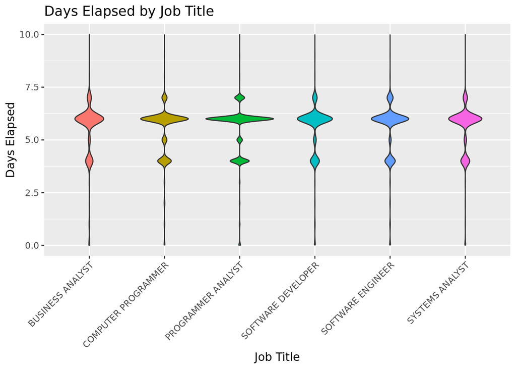

```r
selected_jobs <- c("PROGRAMMER ANALYST", "SOFTWARE ENGINEER", "SOFTWARE DEVELOPER",
                          "SYSTEMS ANALYST", "COMPUTER PROGRAMMER", "BUSINESS ANALYST")
filtered_data <- df2[df2$JOB_TITLE %in% selected_jobs,]

options(repr.plot.width=10, repr.plot.height=6)
violin_plot <- ggplot(filtered_data, aes(x = JOB_TITLE, y = daysElapsed, fill = JOB_TITLE)) +
  geom_violin(trim = FALSE) +
  labs(title = "Days Elapsed by Job Title",
       x = "Job Title",
       y = "Days Elapsed") +
  theme(axis.text.x = element_text(angle = 45, hjust = 1),
        legend.position = "none") +  # Removing legend for better clarity
  scale_y_continuous(limits = c(0, 10))  # Setting y-axis limits

violin_plot
```

To summarize, these visual descriptions allowed for more value to be gained from the variable correlations I predicted to be significant. Although many of the relationships concerning case status and decision turnaround time seem to be negligible, I was able to discover the likely instigator of this issue. The final plot reveals that cases are frequently certified in six days regardless of the case details, deeming other variables inconsequential. This is a very meaningful factor that may make the dataset less ideal to analyze.

# Linear Regression

```r
model <- lm(daysElapsed ~ CASE_SUBMITTED, data = df2)
summary(model)
```

```
Call:
lm(formula = daysElapsed ~ CASE_SUBMITTED, data = df2)

Residuals:
    Min      1Q  Median      3Q     Max
-128.18  -23.66    3.83   16.28  441.57

Coefficients:
                 Estimate Std. Error t value Pr(>|t|)
(Intercept)     1.383e+04  1.336e+01    1036   <2e-16 ***
CASE_SUBMITTED -8.026e-01  7.768e-04   -1033   <2e-16 ***
---
Signif. codes:  0 '***' 0.001 '**' 0.01 '*' 0.05 '.' 0.1 ' ' 1

Residual standard error: 56.55 on 258494 degrees of freedom
Multiple R-squared:  0.8051,    Adjusted R-squared:  0.8051
F-statistic: 1.068e+06 on 1 and 258494 DF,  p-value: < 2.2e-16
```

# Linear Regression Diagnostics

In this section, I will be conducting diagnostics for the linear regression model to truly evaluate its performance. The Residuals vs. Fitted Values plot assesses linearity, aiming for a random scatter around zero. The Normal Q-Q Plot evaluates normality, expecting points along a straight line. The Scale-Location Plot checks for homoscedasticity, with point that should form a horizontal band for constant variance. Lastly, the Residuals vs. Leverage plot identifies influential points and outliers.

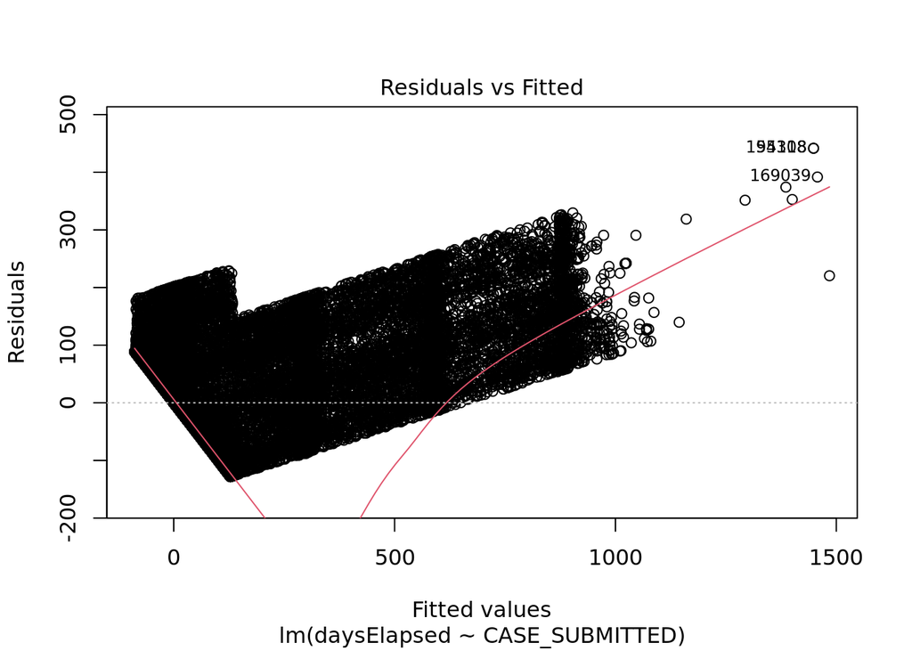

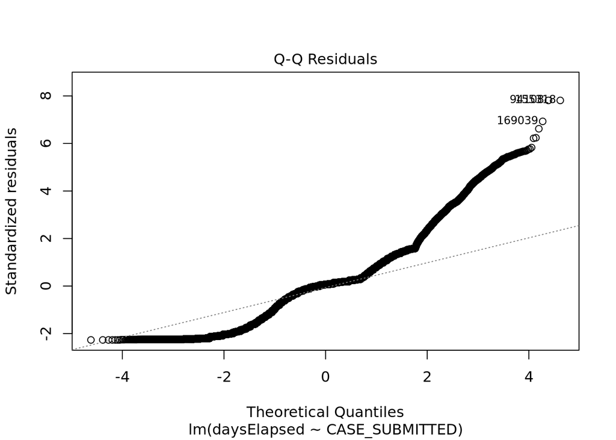

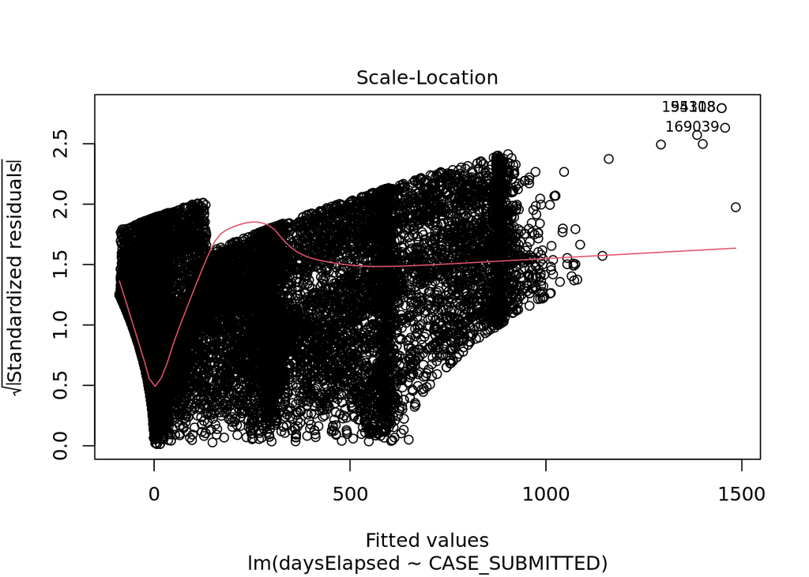

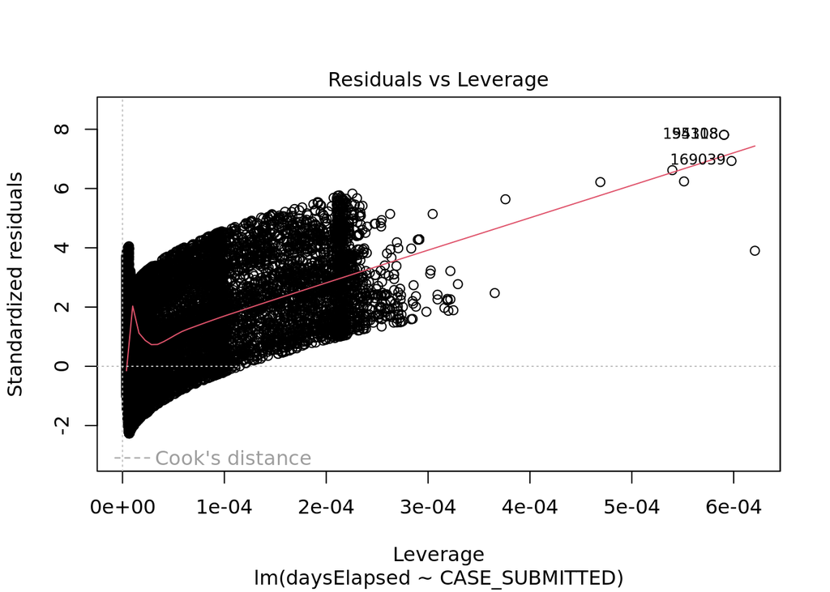

```r
model <- lm(daysElapsed ~ CASE_SUBMITTED, data = df2)
plot(model)
```

It is evident from these plots that the data is not optimal. Firstly, the red line in the Residuals vs Fitted plot is not near the dashed zero line, indicating that the residuals don’t have a mean of about zero. There also seems to be a pattern in the plot, showing that the variance isn’t constant. Next, the Q-Q plot points deviate from the dashed line, meaning the residuals aren’t normally distributed. In the Scale-Location plot, the red line is not fully horizontal, and the points again show somewhat of a pattern, showing non-homoscedasticity. Finally, the Residuals vs. Leverage plot is relatively good due to the lack of many outliers; however, this may be due to the reduced dataframe being used (df2). Overall, these plots don’t decisively follow the expected trends, meaning it is not safe to make any of the desired assumptions.

# Logistic Regression

This final section uses logistic regression to predict visa certification outcomes. The response variable, ‘decision’, is derived from ‘case_status’, and non-certified statuses are consolidated into ‘other’. The ideal results would reveal significant coefficients, highlighting factors influencing certification and providing insights into the determinants of success in the data.

```r
df2 <- df2 |>
  mutate(decision = ifelse(CASE_STATUS == "CERTIFIED", 1, 0))

logistic_model <- glm(decision ~ CASE_SUBMITTED, data = df2, family = "binomial")

summary(logistic_model)
```

```
Call:
glm(formula = decision ~ CASE_SUBMITTED, family = "binomial",
    data = df2)

Coefficients:
                 Estimate Std. Error z value Pr(>|z|)
(Intercept)    -1.614e+02  1.171e+00  -137.8   <2e-16 ***
CASE_SUBMITTED  9.512e-03  6.818e-05   139.5   <2e-16 ***
---
Signif. codes:  0 '***' 0.001 '**' 0.01 '*' 0.05 '.' 0.1 ' ' 1

(Dispersion parameter for binomial family taken to be 1)

    Null deviance: 195564  on 258495  degrees of freedom
Residual deviance: 153509  on 258494  degrees of freedom
AIC: 153513

Number of Fisher Scoring iterations: 5
```

# Conclusion

In conclusion, this comprehensive analysis of the H1B visa dataset provided valuable insights into the factors influencing the certification time frame and outcomes. I began with the data preparation phase, which involved omitting obsolete information and creating a new dataframe with my desired columns. Next, the numerical summary offered a quantitative overview, emphasizing key distributions within the dataset. The visual summary, comprising of bar charts and a violin plot, also depicted the distributional characteristics of important variables and revealed reasoning for some lack of variable correlation. The linear regression analyses then uncovered relationships between ‘case_submitted’ and ‘daysElapsed,’ highlighting the dynamics of H1B visa processing. The subsequent linear regression diagnostics then assessed the model assumptions, deeming the findings to lack reliability. Lastly, the logistic regression delved into predicting certification outcomes, with ‘case_submitted’ evidently emerging as a significant predictor. Overall, the context of this dataset made much of its information irrelevant; however, it underscores the importance of data preparation and model evaluation in deriving value from complex data.